# User’s Manual

# Introduction

# Uploading Data

In the grey left panel of the application, users can upload either a “.txt” a “.csv”, a “.xls”, a .“xlsx” or a “.sav” file.

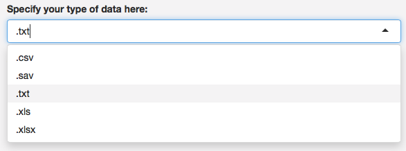

Next to these specifications, the user can choose to only use a certain selection of columns that are present in their data, or to upload all the columns.

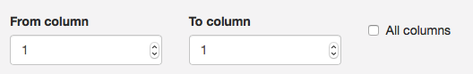

## Data Types

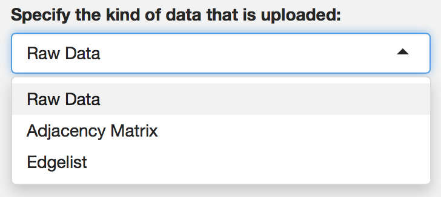

The user can enter three different types of data. The first option is “raw data”. When you have raw data, your datafile consists of columns, which indicate the individual items or variables, and rows that signify each individual participant or measurement of those items or variables. Below is a simplified example of what raw data looks like.

```
##    participant Item1 Item2
## 1            1     5     1
## 2            2     5     5
## 3            3     6     3
## 4            4     4     2
## 5            5     2     5
## 6            6     7     3
## 7            7     7     5
## 8            8     5     4
## 9            9     2     2
## 10          10     2     5
```

The next available option as a data type is the “adjacency matrix”. When you use an adjacency matrix, the data will have the individual items or variables on both the rows and the columns, and each cell indicate whether there is a relation between the two variables, and if so, how strong this relation is. To illustrate, let us take the following adjacency matrix:

```
##   Item1 Item2 Item3 Item4
## 1     0     1     2     1
## 2     1     0     3     2
## 3     2     3     0     1
## 4     1     2     1     0
```

The last available data type is the “edge list”. An edge list is characterized by two columns that depict the starting and ending node for each individual edge, which are represented by the rows. Take for example the edge list below:

```
##   from to
## 1    1  2
## 2    2  3
## 3    3  4
## 4    4  5
## 5    5  1
```

In this example, an edge originates in node 1, and ends in node 2, without the interference of some other node.

In the examples that were previously used, a header existed that shows the variable name for each column. Note that this may help in the identification of nodes when a network is constructed, but that a header is not necessary in order to construct a network.

### Missing Data

After you have specified your data, you can specify the symbol used for missing data, if these exist in your data file. If you do not have any missing data, you can leave this box empty.

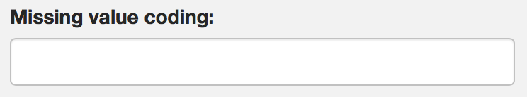

## Example Data

If you do not have any data (yet) that can be used to construct networks, you can download an example data set, which is a raw data file that contains the first 25 variables of the NEO-PI-R. This data is made available via the *psych* package.

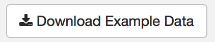

# Network Analysis

After entering all specifications with respect to the data, a network is automatically constructed and displayed on the right, in the tab *Network*:

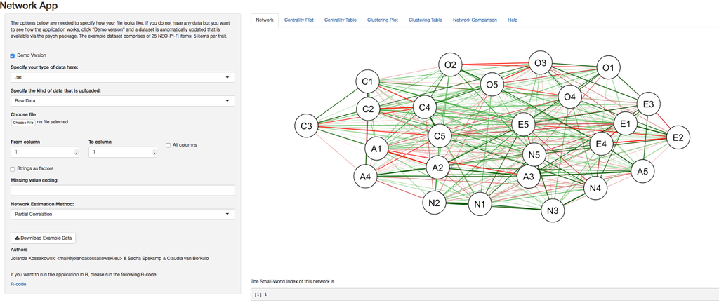

This network is constructed by means of the default values that exist. Almost everything can be changed with respect to the network esthethics, and the estimation of the network. I will explain all options in more detail below.

New in version 1.0.0 is that the network estimation box is now in the grey left panel. This ensures that, when the user selects a certain estimation method, only those options that the user must specify are available to the user.

## Non-Paranormal Transformation

In case that you have continuous data that is non-normally distributed, you can check the *Non-Paranormal Transformation* box. This will transform your data into normally distributed data (Zhao et al. 2014).

## Network Estimation

There are various methods for estimating a network structure. The NetworkApp has employed 11 methods that are used often. Note that the estimation methods only with when you use raw data. As the absence/presence of edges and/or their strength is already specified in an adjacency matrix or edge list, the estimation methods become redundant. The following estimations methods are currently available:

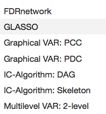

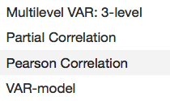

### FDR Network

The *FDR Network* estimation method estimates a network based on the False Discovery Rate (FDR). By setting a cutoff value between 0 and 1, edges with an FDR higher than the cutoff value will be removed from the network.

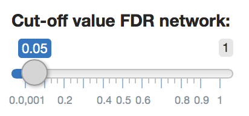

There are three different methods that can be used to create an FDR network:

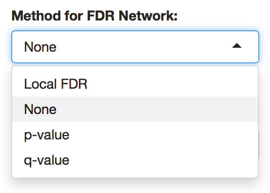

One can use a local false discovery rate, the *p*-value, or the *q*-value. When estimating an FDR network, one is obliged to specify the method and a cut-off value.

### GLASSO

The *GLASSO* estimation method is used to control for spurious correlations that may arise due to multiple testing. To create a sparse network, the EBICglasso, which uses penalized maximum likelihood estimation, is applied to set spurious connections to zero. The result is a network in which connections between nodes represent a nonzero partial correlation, while controlling for all other nodes in the network (Kossakowski et al. 2015).

No further action is required of the user to construct a GLASSO network: by selecting GLASSO, the application will automatically construct this type of network.

### Graphical VAR: PCC

The *Graphical VAR: PCC* estimation method estimates a Graphical Vector Autoregressive (VAR) model with Partial Contemporal Correlations (PCC). By using a LASSO estimation together with the Extended Bayesian Information Criterion (EBIC), sparse networks are constructed. The result of this estimation method is a network in which the edges denote the correlation between two variables at the same time point after removing all linear effects of other variables at the same time point and of all variables at the previous time point (Wild et al. 2010). Note that the Graphical VAR network is appropriate when the data consists of multiple measurements of one participant.

This method is useful when the user wants to estimate a network based on time series data. In order to estimate a proper PCC-network, one has to have all the time points on the rows, and the variables on the columns.

No further action is required of the user to construct a PCC network: by selecting Graphical VAR: PCC, the application will automatically construct this type of network.

### Graphical VAR: PDC

The *Graphical VAR: PDC* estimation method estimates a Graphical Vector Autoregressive (VAR) model with Partial Directed Correlations (PDC). By using a LASSO estimation together with the Extended Bayesian Information Criterion (EBIC), sparse networks are constructed. The result of this estimation method is a lag-1 network in which the edges denote the linear association between two variables, with one being at time point *t*, and the other at timepoint *t-1*, after removing all linear effects of all variables at the previous timepoint. Note that the Graphical VAR network is appropriate when the data consists of multiple measurements of one participant.

This method is useful when the user wants to estimate a network based on time series data. In order to estimate a proper PDC-network, one has to have all the time points on the rows, and the variables on the columns.

No further action is required of the user to construct a PDC network: by selecting Graphical VAR: PDC, the application will automatically construct this type of network.

### IC-Algorithm: DAG

The *IC-Algorithm: DAG* estimation method can be used to construct a *Directed Acyclic Graph* (DAG) by using the *Inferred Causation (IC) Algorithm* (Pearl 2009). This DAG is created by means of the *pcalg* package (Kalisch et al. 2012). This function estimates the equivalence class of a DAG, which means that multiple networks can describe the same set of conditional independencies. More specifically, a *Completed Partially Directed Acyclic Graph* (CPDAG) is estimated, which is a network that may contain both directed and undirected edges. A directed edges is drawn when this edge is present in all DAGS in the equivalence class, and an undirected edge is drawn when at least one DAG contains the edge with direction a –> b, and at least one DAG that contains the same edge, but with direction b –> a.

When the user wants to estimate a DAG, one also has to specify which method is to be used to test the conditional independencies:

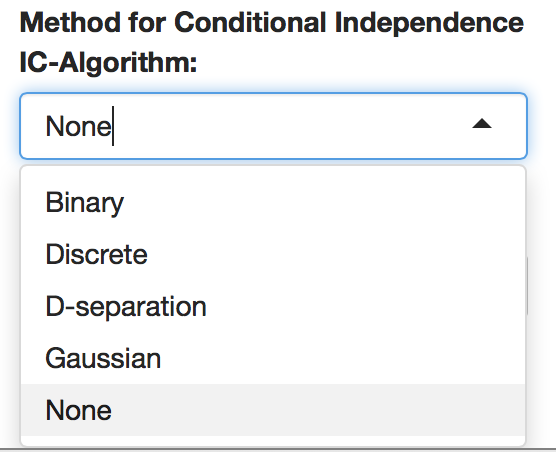

The choice of method mainly depends on the data: If the data contains Gaussian data, the user would choose Gaussian. The same holds for Binary data and Discrete (multinomial) data. D-separation is a special method that states that two variables are conditionally independent controlling for a third variable if that third variable blocks ALL paths between the initial two variables.

### IC-Algorithm: Skeleton

The *IC-Algorithm: Skeleton* is an estimation method that estimates the skeleton of a Directed Acyclic Graph (DAG) using the PC-algorithm. The result is an undirected network. As with the DAG estimation method, the user has to specify the function that is used for testing conditional independence. All conditional independencies are tested with an alpha of 0.05.

### Multilevel VAR: 2-level

The *Multilevel VAR: 2-level* is an estimation method that estimates a multivariate vector autoregression parameters between variables. The 2-level version is appropriate for time-series data that contains multiple participants and multiple measurements (either on the day-level or within the day-level). The result of this type of network is a directed network that contains the relation between variables over time, and the effect of a variable on itself over time (Mõttus, Epskamp, and Francis Submitted for Publication).

In order to properly estimate a multilevel VAR network, you must select “all columns” when uploading your data.

When a user wants to estimate a multilevel VAR network with two levels, one has to first specify which variable holds the participant numbers:

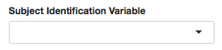

Also, because the datafile holds several columns that are only used to identify the individual measurement, the user must specify which columns contain the actual data that you want to use in your estimation.

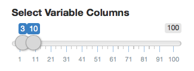

An information criterion is used to select the best fitting model, which is in turn visualized as a network. The default is the *Akaike Information Criterion* (AIC), but one can also choose the *Bayesian Information Criterion* (BIC):

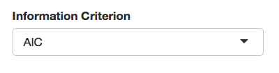

In VAR-models, one typically looks at the effect of a variable on all other variables and on itself at the next time point. This means that the time lag used to find the proper effect is 1. In some cases, it may be interesting to see what the effect of a variable is when this time lag is different. It is therefore possible to set the time lag. Note that it may return an error when a time lag is chosen that is larger than the amount of measurements per person.

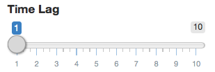

Some users may want to fix how many edges may end at a variable. If you do not have a preference for this, you can set the maximum incoming edges to the equal to the amount of variables in your network.

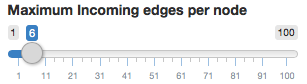

By default, the multilevel VAR network uses a stepwise procedure to find the best fitting network. By unchecking this option, the application will run a nodewise procedure in order to find the best fitting combination of edges and edge weights.

### Multilevel VAR: 3-level

The *Multilevel VAR: 3-level* is an estimation method that estimates a multivariate vector autoregression parameters between variables. The 3-level version is appropriate for time-series data that contains multiple participants, measurements over multiple days and multiple measurements within a day.

Next to all the options that are available in the 2-level network, the user also has to specify the column name that contains the day variable, as we are now constructing a 3-level network.

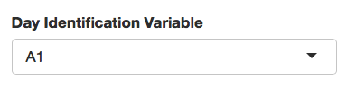

### Partial Correlation

The *Partial Correlation* estimation method estimates the correlation between two variables, controlling for all other variables in the network. No further action is required of the user to construct a partial correlation network: by selection Partial Correlation, the application will autimatically construct this type of network.

### Pearson Correlation

The *Pearson Correlation* method is a method that estimates the correlation between two variables. The result is a network in which all correlations are displayed. No further action is required of the user to construct a correlation network: by selection Pearson Correlation, the application will autimatically construct this type of network.

### VAR-model

The *VAR-model* estimation method estimates a *vector autoregressive lag-1* (VAR) model using General Linear Models (GLM). By using GLM, each node is predicted based on all other nodes at the previous time point. The edges in the resulting network represent the lag-1 association between two variables.

This method is useful when the user wants to estimate a network based on time series data. In order to estimate a proper VAR-network, one has to have all the time points on the rows, and the variables on the columns.

In order to run the VAR-model estimation method, the user has to specify the distribution family of the data:

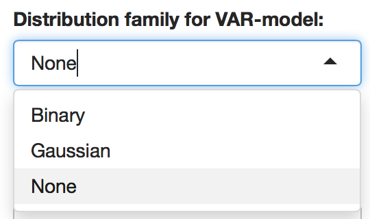

There are currently two options: the data can either be binary or continuously measured. In cas e of the first, the user selects binary, and in case of the latter, the user chooses Gaussian.

## Small World Index

The *Small World Index* (SWI) is an index that tells you whether a network is in fact a small world or not. A Small World Network is a network in which the average distance between two nodes resembles that of a Random Network, and where the average ratio between the amount of existing edges and possible edges (*clustering*) is high in comparison to a Random Network (Watts and Strogatz 1998).

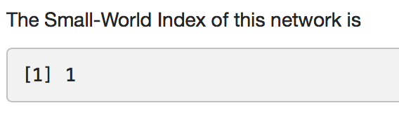

A network is considered a Small World Network when the SWI is higher or equal to 3. The SWI is automatically calculated for each network that is constructed, and will be re-calculated when parameters are changed.

## Download Network

Each network that is constructed can be download as a .pdf file by clicking on the corresponding button:

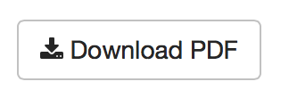

# Network Esthethics

After you have selected the estimation method that you want to use to construct a network, a network is plotted. The user can then go on and change different esthethics.

## General

### Title

The user can enter a title, which is then displayed above the network, both in the app itself and in the pdf file that can be downloaded.

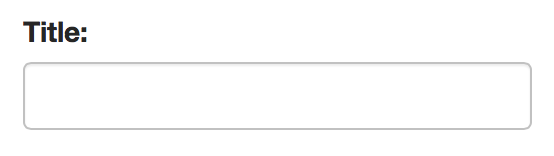

### Network Layout

There are two options for node placement in the NetworkApp:

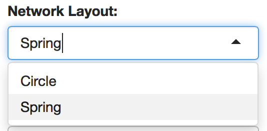

The *Circle* layout will place all the node in a circle. The *Spring* layout uses the Fruchterman-Reingold Algorithm (Fruchterman and Reingold 1991) that places more strongly connected nodes closer together. The Spring layout is used by default.

### Graph Details

If the option *Graph Details* is checked, the cuf-off value and the maximum edge weight is displayed below the network. The graph details will also be displayed on the pdf version, if the option is checked before downloading the figure.

## Node Esthethics

### Node Size

The size of the nodes can be adjusted by changing the slider that is displayed below:

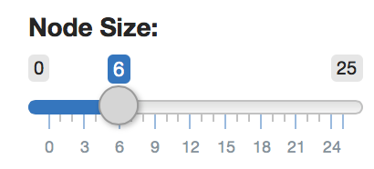

Depending on the value, the size of the nodes will either be increased or decreased to one’s taste.

### Node Shape

The user can change the shape of the node to one of the following shapes that speak for themselves:

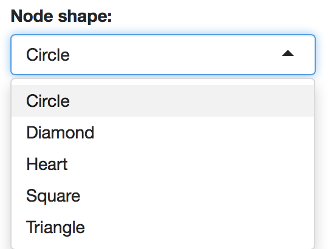

### Node Labels

The labels that are displayed within the nodes are subtracted from the header if present in the datafile. If needed, the user can uncheck this option, which will ensure that the nodes are displayed without any text.

## Edge Esthethics

### Edge Size

As with the size of the nodes, the size of the edges can be adjusted as well, by changing the value of the following slider:

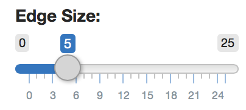

When the network contains directed edges, the size of the arrow will be adjusted relative to the size of the edges.

### Edge Weights

If edge weights exist in the datafile that is uploaded, these will automatically be displayed. However, it is possible that you want to construct a network without taking the edge weights into account. By unchecking this box, the network will become unweighted.

### Directed Edges

As is the case for the edge weights, it is possible to force the edges to have a direction, or to change a directed network into an undirected one. When the user constructs a PDC-network, one has to check this option in order to see the appropriate network.

### Plot Self-Loops

It may be interesting or useful to plot edges that originate and end in the same node, so-called *self-loops*. By checking this box, self-loops will be automatically drawn and visualized.

### Edge Threshold

By adjusting this slider, the user can control the value below which the edges are removed from the network. If the edge threshold is changed, the spring layout will also change, next to the results from centrality analyses.

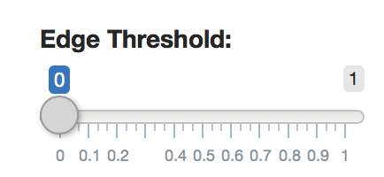

### Minimum Edge Weight

In order to make a network more interpretable, it is possible to not display edges below a certain value. By adjusting the slider below, the user can control the value above which edges are displayed.

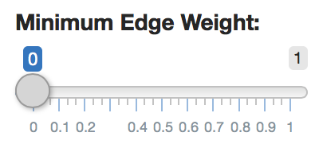

This option differs from the edge threshold, in that the edge threshold option will remove the edge, whereas the minimum edge weight option will not remove the edges, but will not display them either.

### Maximum Edge Weight

The user can change this slider to make various networks more comparable. By setting the maximum edge weight, the application will adjust the edge thickness and saturation accordingly.

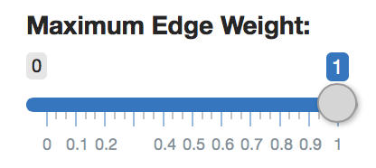

### Edge Cut-Off Value

The *Cut-Off* option can be used to change the scaling of the edges’ thickness and saturation. Edges with an absolute above the set value will have the most saturated colour, and will vary in thickness as the edges become stronger. Edges with an absolute weight below the set value will have the thickness, but will vary in saturation according to the edge weight.

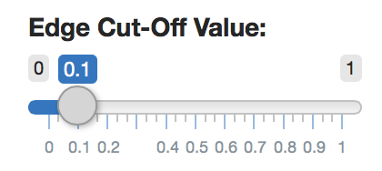

# Centrality Analyses

In network analysis, centrality analyses are used to determine a node’s importance in the network (Costantini et al. 2015). A node’s importance can be assessed in different ways: the most used measures are the *strength*, the *closeness* and the *betweenness*.

## Centrality plot

When you click on the *centrality plot* tab, the default centrality measures (closeness and betweenness) are visualized:

[figure not shown]

### Standardized Centrality Measures

Centrality measures are by default standardized, but you can uncheck this option in order to obtain the raw centrality measures.

### Strength

The *strength* is calculated by summing up the edge weights that are connected to a specific node. By taking the edge weights into account, the strength shows us not which node has the most connections, but which node has the strongest connections. A node with a high strength centrality is a node that influences many other nodes.

### Betweenness

The *betweenness* is the amount of shortests paths between any two nodes (the shortest route from node A to node B) that pass a specific node. A node with a high betweenness centrality is considered a “hub”, a node through which the most shortest paths go through.

### Closeness

The *closeness* is the inverse of the sum of the distance from one node to all other nodes in the network. As such, the closeness show the predictive quality that a specific node may have. A node with a high closeness centrality is a node is a node from which it is easy to travel to all other nodes. In other words, a node with a high closeness centrality is a node that can predict other nodes well.

### Out Strength

The *Out Strength* is the exact opposite of the in strength. So, instead of summing up the weights of all incoming edges, the out strength is calculated by summing up the weights of all outgoing edges. This means that a node with a high out strength is one that influences a lot of other nodes, as many edges originate in that specific node.

### Download Centrality Plot

After chosing the centrality measures and deciding on the plot layout, the centrality plot can be downloaded as a .pdf file.

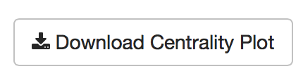